# Econometría Aplicada con R

Sesión 04: Introducción a series de tiempo

Javier Emmanuel Anguiano Pita

SECIHTI-Universidad de Guadalajara

18 de junio de 2026

## Agenda del día

1. Introducción a series de tiempo.
2. Estacionalidad.
3. Regresiones espurias.
4. Raíces unitarias y estacionariedad.
5. Pruebas de causalidad de Granger.

# Motivación

## ¿Por qué series de tiempo?

Hasta ahora hemos trabajado con datos de **corte transversal** — una fotografía de múltiples individuos en un momento dado.

**Las series de tiempo añaden una dimensión nueva: el orden temporal importa.**

- Los errores de hoy pueden estar correlacionados con los de ayer
- Las variables pueden mostrar tendencias o ciclos sistemáticos
- Las relaciones de largo plazo difieren de las de corto plazo

Aplicaciones en economía: PIB, inflación, tipo de cambio, tasas de interés, desempleo…

# Autocorrelación en series de tiempo

## Autocorrelación en series de tiempo

En series de tiempo el supuesto de errores no correlacionados es especialmente frágil:

$$Cov(\varepsilon_t, \varepsilon_{t-s}) = 0 \quad \forall s \neq 0$$

A diferencia del corte transversal, en series de tiempo cada observación **hereda información de las anteriores**:

- El PIB de hoy depende del PIB de ayer
- El tipo de cambio refleja su valor de la semana pasada

Si el modelo no captura esa dinámica, la información no explicada queda atrapada en los residuales:

$$\varepsilon_t = \rho \varepsilon_{t-1} + u_t \quad |\rho| < 1$$

Este proceso se llama **AR(1) en el error** — es el caso más común de autocorrelación en series de tiempo en economía.

## Consecuencias de la autocorrelación

Si $Cov(\varepsilon_t, \varepsilon_{t-1}) \neq 0$:

**Qué se mantiene**

- MCO sigue siendo **insesgado**
- Los coeficientes apuntan en la dirección correcta

**Qué no se cumple**

- MCO deja de ser **eficiente** — no es MELI
- Errores estándar **subestimados**
- Estadísticos $t$ y $F$ **inflados**
- Rechazamos $H_0$ más de lo debido
- Predicciones **subóptimas**

El problema no es el sesgo — es la **inferencia incorrecta**: los intervalos de confianza son demasiado estrechos y los p-values demasiado pequeños

## Prueba de Durbin-Watson

Detecta **autocorrelación de primer orden** en los residuales:

$$H_0: \rho = 0 \quad \text{(no hay autocorrelación)}$$
$$H_1: \rho \neq 0 \quad \text{(existe autocorrelación)}$$

$$DW = \frac{\sum_{t=2}^{T} (\hat{\varepsilon}_t - \hat{\varepsilon}_{t-1})^2}{\sum_{t=1}^{T} \hat{\varepsilon}_t^2}$$

**Interpretación:**

| Valor de DW | Interpretación |
| --- | --- |
| $DW \approx 2$ | No hay autocorrelación |
| $DW < 2$ | Autocorrelación positiva |
| $DW > 2$ | Autocorrelación negativa |
| $DW \approx 0$ | Autocorrelación positiva severa |
| $DW \approx 4$ | Autocorrelación negativa severa |

El estadístico DW tiene su propia distribución. 🚨 No es una t-Student o F.

## Durbin-Watson en R

Estimamos nuestro modelo de regresión y evalúamos si los residuales presentan autocorrelación:

```r
library(lmtest)

m_1 <- lm(log(INPC) ~ log(TC), data = datos)
dwtest(m_1)
```

[output not shown]

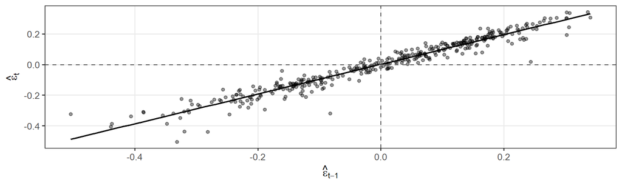

Un DW cercano a cero confirma lo que vemos en la gráfica — los residuales tienen estructura y no son ruido blanco

## Ruido blanco vs. proceso autocorrelacionado

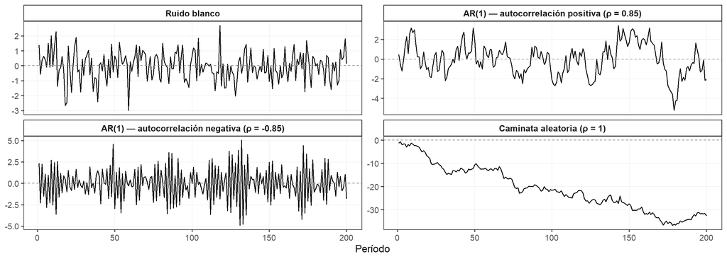

El ruido blanco oscila alrededor de cero sin patrón — con autocorrelación positiva los valores se mueven suavemente, con negativa oscilan bruscamente.

# Estacionalidad

## Componentes de una serie de tiempo

Una serie de tiempo $y_t$ puede descomponerse en:

$$y_t = T_t + S_t + C_t + \varepsilon_t$$

donde:

- $T_t$ — **tendencia**: movimiento de largo plazo
- $S_t$ — **estacionalidad**: patrón regular que se repite dentro del año
- $C_t$ — **ciclo**: fluctuaciones de mediano plazo (negocios)
- $\varepsilon_t$ — **componente irregular**: ruido no sistemático

La descomposición puede ser **aditiva** ($y_t = T_t + S_t + \varepsilon_t$) o **multiplicativa** ($y_t = T_t \times S_t \times \varepsilon_t$).

## Estacionalidad: definición

La **estacionalidad** es un patrón sistemático y predecible que se repite con una frecuencia fija dentro del año.

**Ejemplos:**

- Ventas minoristas — pico en diciembre (Navidad)
- Desempleo — aumenta en enero (fin de contratos temporales)
- Turismo — concentrado en verano
- Producción agrícola — ciclos de siembra y cosecha

**¿Por qué importa en econometría?**

Si no corregimos la estacionalidad, podemos confundir variación estacional con efectos causales de las variables explicativas.

## Ejemplo de estacionalidad `AirPassangers`

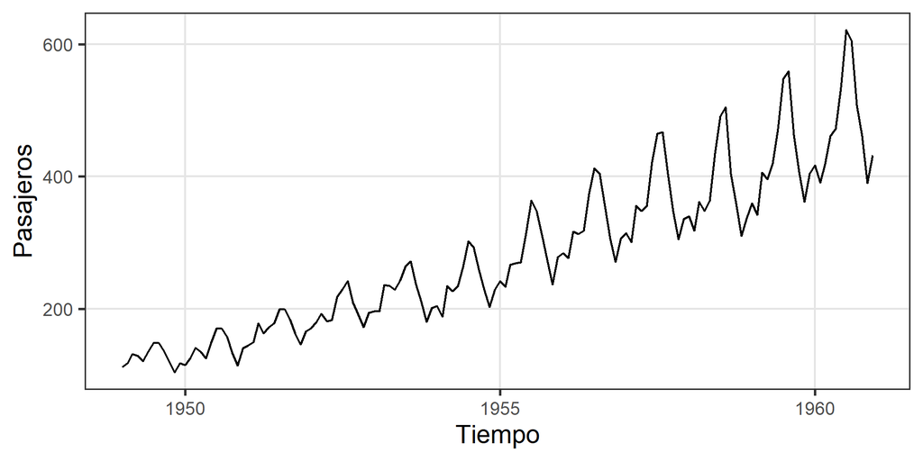

## Descomposición en R

Usamos la función `decompose()` con datos de pasajeros que viajan en avión `AirlinePassengers`:

```r
data("AirPassengers")

?AirPassengers

# Descomposición aditiva
desc <- decompose(AirPassengers, type = "additive")
plot(desc)
```

Para desestacionalización formal se recomienda el método **X-13ARIMA-SEATS** (INEGI lo usa en sus series oficiales), disponible en el paquete `seasonal`.

## Dummies estacionales

Una forma sencilla de estudiar los patrones estacionales de una series es modelarla utilizando **variables dicotómicas** por trimestre/mes:

$$y_t = \beta_0 + \sum_{s=2}^{4} \delta_s D_{st} + \beta_1 x_t + \varepsilon_t$$

**Pasos a seguir:**

1. Estimar modelo de regresión con dummies (por frecuencia).
2. Verificar pruebas de hipótesis para validad estacionalidad.
3. Calcular valores ajustados por la regresión y restarles el intercepto.
4. Ajustar la serie de la siguiente forma:

$$y_{sa} = y_{obs} - \text{componente estacional}$$

El trimestre omitido es la **categoría de referencia** — los coeficientes $\delta_s$ miden la desviación de cada trimestre respecto al primero.

## Desestacionalización con X-13ARIMA-SEATS

En la práctica aplicada los institutos de estadística usan métodos más sofisticados que las dummies:

```r
library(readxl)
library(tidyverse)

imai <- read_excel("../Datos/DATOS_SERIES_TIEMPO.xlsx",
                   sheet = "IMAI")

# X-13 requiere un objeto ts
library(seasonal)

imai_ts <- ts(imai$IMAI,
            start = c(1993, 1),
            frequency = 12)

# Estimar el modelo de desestacionalización
ajuste_imai <- seas(imai_ts)

# Extraer la serie desestacionalizada
imai_desest <- final(ajuste_imai)
```

`seas()` implementa X-13ARIMA-SEATS — el método estándar de la Reserva Federal, Eurostat, INEGI y Banxico para desestacionalizar series oficiales

# Ejemplo: IMAI México

## Desestacionalización del IMAI

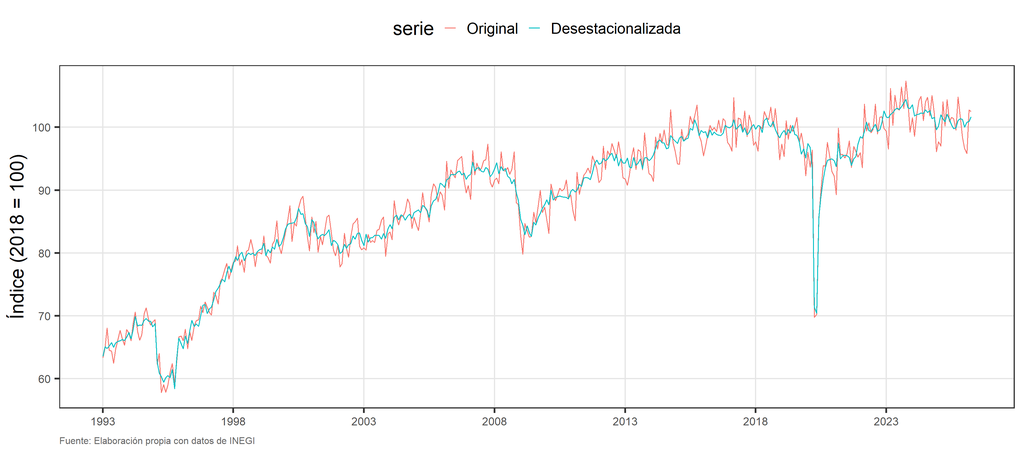

La serie desestacionalizada elimina las fluctuaciones mensuales regulares y deja visible la tendencia y el ciclo económico — los quiebres de 2008-09 y 2020 se pueden identificar claramente.

# Fin del primer bloque 🗣

# Regresiones espurias

## Caminata aleatoria (Random Walk)

En estadística, una **caminata aleatoria** es un proceso estocástico en el que el valor actual de una variable es igual a su valor pasado más un choque aleatorio

$$y_t = y_{t-1} + u_t$$

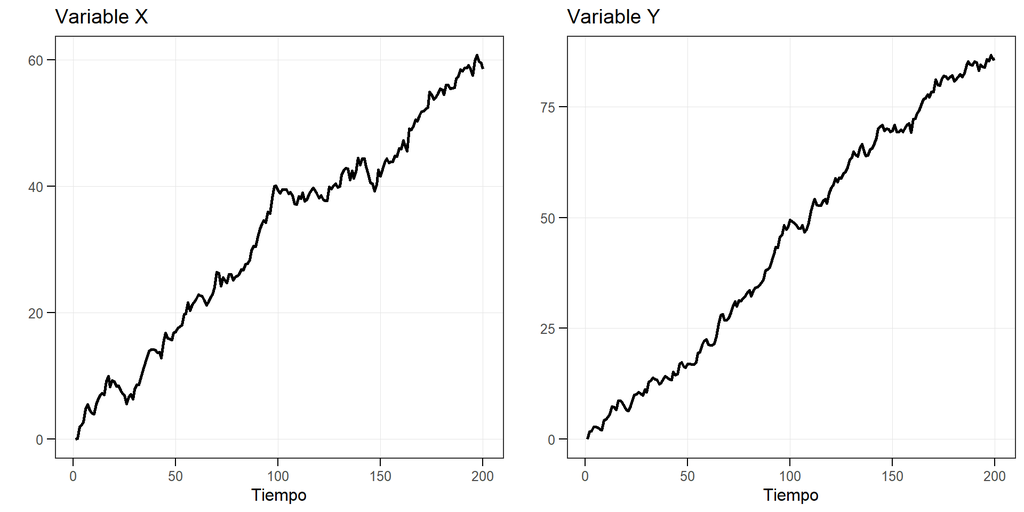

## El problema de la regresión espuria

Considera dos series independientes que **comparten una tendencia temporal**:

$$y_t = \alpha_0 + \alpha_1 t + u_t$$
$$x_t = \gamma_0 + \gamma_1 t + v_t$$

Si estimamos $y_t = \beta_0 + \beta_1 x_t + \varepsilon_t$, obtendremos:

- $\hat{\beta}_1$ significativo con $t$ grande
- $R^2$ elevado
- **Pero la relación es completamente espuria**

**MCO estándar falla cuando las series no son estacionarias** — los supuestos de Gauss-Markov no se cumplen.

## Regresión espura

Granger & Newbold (1974) demostraron mediante simulaciones que hacer una regresión con dos caminatas aleatorias independientes produce:

| Variable | Coeficiente | Error estándar | Estadístico t | P-value | Significancia |
| --- | --- | --- | --- | --- | --- |
| (Intercept) | -6.6652 | 0.7502 | -8.8851 | 0.0000 | *** |
| x | 1.6044 | 0.0207 | 77.5398 | 0.0000 | *** |
| R² | 0.9681 | NA | NA | NA |  |
| R² ajustado | 0.9680 | NA | NA | NA |  |

Resultado típico: $R^2 > 0.8$, $p$-value $< 0.001$, pero **ninguna relación real existe entre** $y$ **y** $x$.

## ¿Cuándo es espuria una regresión?

Señales de alerta en series de tiempo no estacionarias:

**Síntomas estadísticos**

- $R^2$ muy alto con DW cercano a cero
- Coeficientes “significativos” pero sin sentido económico
- Residuales con tendencia clara (no ruido blanco)

**Diagnóstico**

- Estadístico de Durbin-Watson $\approx 0$
- Residuales no estacionarios (raíz unitaria)
- Gráfica de residuales con deriva (*drift*)

**Regla de Granger-Newbold:** si $R^2 > DW$, sospechar regresión espuria.

## Ejemplo: regresión espuria

Supongamos que estimamos el siguiente modelo:

$$\ln INPC_t = \beta_0 + \beta_1 \ln TC_t + \varepsilon_t$$

[output not shown]

## Ejemplo: regresión espuria

```
    Durbin-Watson test

data:  m1
DW = 0.057204, p-value < 2.2e-16
alternative hypothesis: true autocorrelation is greater than 0
```

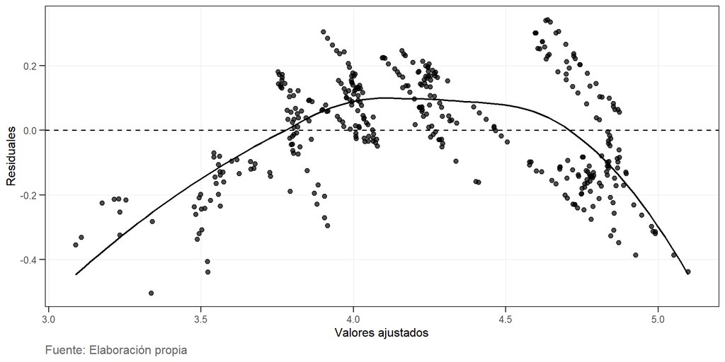

# Estacionariedad y raíces unitarias

## Proceso estocástico

Una serie de tiempo es una **realización** de un proceso estocástico:

$$\{y_t\}_{t=1}^{T} = \{y_1, y_2, \ldots, y_T\}$$

Un **proceso estocástico** es una colección de variables aleatorias indexadas en el tiempo — cada observación $y_t$ es el resultado de un mecanismo generador de datos con sus propias propiedades estadísticas

**Lo que observamos**

Una sola trayectoria del proceso — la historia realizada del PIB, el tipo de cambio o las remesas

**Lo que asumimos**

Que esa trayectoria es suficientemente informativa para estimar las propiedades del proceso que la generó

El supuesto de **estacionariedad** es lo que hace posible aprender sobre el proceso a partir de una sola realización

## Proceso estocástico estacionario

Un proceso estocástico $\{y_t\}$ es **débilmente estacionario** si:

$$E[y_t] = \mu \quad \forall t$$
$$\text{Var}(y_t) = \sigma^2 < \infty \quad \forall t$$
$$\text{Cov}(y_t, y_{t-h}) = \gamma(h) \quad \forall t$$

La media, la varianza y las autocovarianzas **no dependen del tiempo** — solo del rezago $h$.

La estacionariedad es un supuesto central en series de tiempo: sin ella, los estimadores MCO son inconsistentes y las pruebas $t$ y $F$ no son válidas.

## Procesos no estacionarios: tipología

**Tendencia determinista (DS)**

$$y_t = \alpha + \delta t + \varepsilon_t$$

- La tendencia es una función fija del tiempo
- Se corrige **restando la tendencia** (detrending)
- Los choques tienen efectos **transitorios**

**Tendencia estocástica (TE)**

$$y_t = y_{t-1} + \varepsilon_t$$

- La tendencia emerge de la acumulación de choques aleatorios
- Se corrige tomando **primeras diferencias**
- Los choques tienen efectos **permanentes**

Confundir TD con TE (o viceversa) lleva a conclusiones incorrectas sobre la persistencia de los choques.

## La caminata aleatoria

El proceso no estacionario más simple es la **caminata aleatoria**:

$$y_t = y_{t-1} + \varepsilon_t, \quad \varepsilon_t \sim \text{iid}(0, \sigma^2)$$

Propiedades:

- $E[y_t] = y_0$ — la media no cambia, pero…
- $\text{Var}(y_t) = t\sigma^2$ — la varianza **crece con el tiempo**
- $\text{Cov}(y_t, y_{t-h}) = (t-h)\sigma^2$ — depende de $t$

La solución recursiva muestra que $y_t = y_0 + \sum_{i=1}^{t} \varepsilon_i$ — cada shock se acumula permanentemente.

## Raíces unitarias: definición formal

Considera el proceso AR(1):

$$y_t = \rho \, y_{t-1} + \varepsilon_t$$

- Si $|\rho| < 1$: proceso **estacionario** — choques se disipan
- Si $\rho = 1$: **raíz unitaria** — choques permanentes (caminata aleatoria)
- Si $\rho > 1$: proceso **explosivo** — raro en economía

La denominación “raíz unitaria” proviene del polinomio de rezagos:

$$y_t - \rho L y_t = \varepsilon_t \implies (1 - \rho L) y_t = \varepsilon_t$$

La “raíz” es el valor de $L$ que hace cero el polinomio: $L = 1/\rho$. Cuando $\rho = 1$, la raíz vale 1.

## Persistencia de los choques

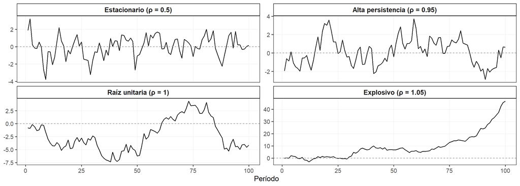

Con $\rho = 0.5$ los choques se disipan rápidamente — con $\rho = 0.95$ persisten largamente — con $\rho = 1$ se acumulan permanentemente — con $\rho > 1$ la serie diverge

## Procesos integrados

Una serie con raíz unitaria que se vuelve estacionaria al diferenciarla **una vez** se llama integrada de orden 1: $y_t \sim I(1)$.

**Notación general:**

- $y_t \sim I(0)$: estacionaria en niveles
- $y_t \sim I(1)$: estacionaria en primeras diferencias ($\Delta y_t$)
- $y_t \sim I(2)$: estacionaria en segundas diferencias ($\Delta^2 y_t$)

**Regla práctica:**

$$\Delta y_t = y_t - y_{t-1}$$

Si $y_t \sim I(1)$, entonces $\Delta y_t \sim I(0)$ — la diferenciación “elimina” la raíz unitaria.

La mayoría de las series macroeconómicas son $I(1)$: PIB, precios, tasas de interés, tipo de cambio.

## Diferenciación: de tendencia a constante

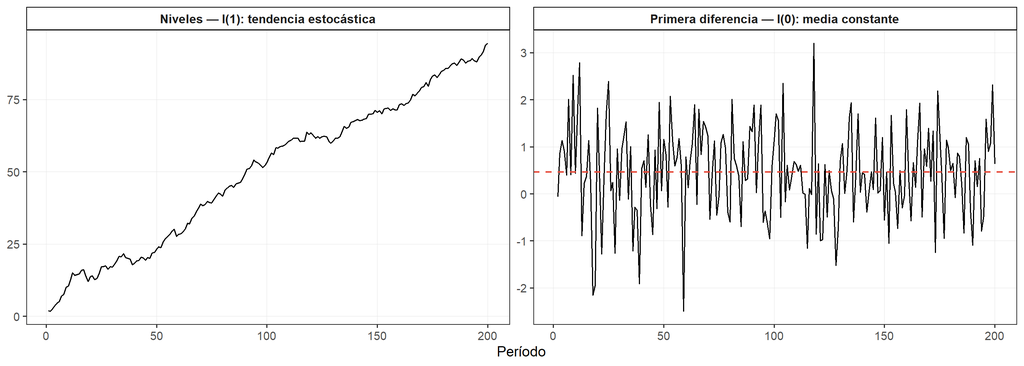

La serie en niveles tiene tendencia creciente — al diferenciar la tendencia desaparece y la serie fluctúa alrededor de una **media constante** (línea roja)

# Detección de raíces unitarias

## Prueba de Dickey-Fuller aumentada (ADF)

La **prueba ADF** es el estándar para detectar raíces unitarias. Se basa en estimar:

$$\Delta y_t = \alpha + \delta t + \pi y_{t-1} + \sum_{j=1}^{p} \phi_j \Delta y_{t-j} + \varepsilon_t$$

**Hipótesis:**

$$H_0: \pi = 0 \quad \text{(raíz unitaria — serie no estacionaria)}$$
$$H_1: \pi < 0 \quad \text{(serie estacionaria)}$$

Los valores críticos **no son los de la distribución normal** — Dickey y Fuller (1979) derivaron la distribución correcta mediante simulación. En R: `tseries::adf.test()` o `urca::ur.df()`.

## Especificación de la prueba ADF

La elección de la especificación afecta los valores críticos:

**Sin constante ni tendencia**

$$\Delta y_t = \pi y_{t-1} + \ldots$$

Para series centradas en cero

**Con constante**

$$\Delta y_t = \alpha + \pi y_{t-1} + \ldots$$

La más usada en práctica

**Con constante y tendencia**

$$\Delta y_t = \alpha + \delta t + \pi y_{t-1} + \ldots$$

Para series con tendencia visible

**Regla práctica:** elegir la especificación según la gráfica de la serie. Si la serie tiene tendencia visible, incluir tendencia en la prueba.

## Selección de rezagos en la prueba ADF

El número de rezagos $p$ en la prueba ADF es una decisión crítica:

**Pocos rezagos**

- Los residuales pueden seguir autocorrelacionados
- El estadístico ADF está sesgado
- Se rechaza $H_0$ con más frecuencia de lo debido
- **Sobreestima la estacionariedad**

**Demasiados rezagos**

- Se pierden grados de libertad
- La prueba pierde potencia
- Es más difícil rechazar $H_0$
- **Sobreestima la no estacionariedad**

## Selección de rezagos en la prueba ADF

**Solución: selección automática con criterio de información**

```r
library(urca)

# Selección automática de rezagos con AIC — hasta 12 rezagos
adf_auto <- ur.df(y_ts,
                  type       = "trend",  # "none", "drift", "trend"
                  lags       = 12,
                  selectlags = "AIC")

summary(adf_auto)
```

`ur.df()` de `urca` selecciona automáticamente el número óptimo de rezagos — `adf.test()` de `tseries` usa una fórmula fija que puede no ser adecuada para todas las series

## Prueba ADF con constante y tendencia

$$\Delta y_t = \alpha + \delta t + \pi y_{t-1} + \sum_{j=1}^{p} \phi_j \Delta y_{t-j} + \varepsilon_t$$

| Estadístico | $H_0$ | Prueba |
| --- | --- | --- |
| `tau3` | $\pi = 0$ | Raíz unitaria — **el principal** |
| `phi3` | $\pi = 0$ y $\delta = 0$ | Raíz unitaria sin tendencia |
| `phi2` | $\pi = 0$, $\alpha = 0$ y $\delta = 0$ | Raíz unitaria sin constante ni tendencia |

```r
ur.df(y_ts, type = "trend", lags = 12, selectlags = "AIC")
```

Usar cuando la serie tiene **tendencia visible** en la gráfica — típico para PIB, precios y tipo de cambio en niveles

## Prueba ADF con constante

$$\Delta y_t = \alpha + \pi y_{t-1} + \sum_{j=1}^{p} \phi_j \Delta y_{t-j} + \varepsilon_t$$

| Estadístico | $H_0$ | Prueba |
| --- | --- | --- |
| `tau2` | $\pi = 0$ | Raíz unitaria — **el principal** |
| `phi1` | $\pi = 0$ y $\alpha = 0$ | Raíz unitaria sin constante |

```r
ur.df(y_ts, type = "drift", lags = 12, selectlags = "AIC")
```

Usar cuando la serie fluctúa alrededor de una media distinta de cero pero **sin tendencia visible** — típico para primeras diferencias

## Prueba KPSS

La prueba **KPSS** (Kwiatkowski, Phillips, Schmidt y Shin, 1992) invierte las hipótesis:

$$H_0: \text{serie estacionaria}$$
$$H_1: \text{raíz unitaria}$$

**¿Por qué usarla junto con ADF?**

- ADF tiene baja potencia (tiende a no rechazar $H_0$)
- KPSS complementa: si ADF no rechaza $H_0$ (RU) **y** KPSS no rechaza $H_0$ (estacionaria), hay evidencia contradictoria

La estrategia recomendada es **aplicar ambas pruebas** y comparar resultados.

## Prueba KPSS: especificación

Al igual que la ADF, la KPSS puede estimarse con dos especificaciones:

**Sin tendencia** (`null = "Level"`)

$$H_0: \text{serie estacionaria en nivel}$$

Adecuada para series que fluctúan alrededor de una **media constante**

```r
kpss.test(y_ts, null = "Level")
```

**Con tendencia** (`null = "Trend"`)

$$H_0: \text{serie estacionaria en tendencia}$$

Adecuada para series que crecen o decrecen **sistemáticamente**

```r
kpss.test(y_ts, null = "Trend")
```

## Aplicación: PIB de México

Estudiemos las propiedades de integración del PIB de México usando las librerías `urca` y `tseries`

```r
library(readxl)
library(tseries)
library(urca)

# Cargar serie
pib <- read_excel("../Datos/DATOS_SERIES_TIEMPO.xlsx",
                  sheet = "PIB")
pib_ts <- ts(log(pib$PIB), start = c(1993,1), frequency = 4)


# Prueba ADF (con constante y tendencia)
pib_adf <- ur.df(pib_ts, type = "trend", selectlags = "AIC")
summary(pib_adf)

adf.test(pib_ts)

# Prueba KPSS
kpss.test(pib_ts, null = "Level")

# Prueba en primeras diferencias
adf.test(diff(pib_ts))
```

Si el PIB en niveles es $I(1)$, la tasa de crecimiento ($\Delta \ln PIB_t$) debe ser $I(0)$.

# Fin del segundo bloque 🗣

# Causalidad de Granger

## Causalidad de Granger

**Granger (1969):** “$x$ causa a $y$ en el sentido de Granger si el pasado de $x$ ayuda a predecir $y$, más allá de lo que ya predice el pasado de $y$”

**No implica causalidad estructural** — detecta *precedencia temporal con valor predictivo*

Formalmente, $x$ causa Granger a $y$ si al agregar los rezagos de $x$ al modelo de predicción de $y$, la capacidad predictiva **mejora significativamente**:

$$y_t = \alpha + \sum_{i=1}^{p} \phi_i y_{t-i} + \sum_{j=1}^{p} \beta_j x_{t-j} + \varepsilon_t$$

$$H_0: \beta_1 = \beta_2 = \cdots = \beta_p = 0$$

Se rechaza $H_0$ con una **prueba F** — si los $\beta_j$ son conjuntamente significativos, $x$ causa Granger a $y$

## Posibles resultados

La prueba se aplica en **ambas direcciones** — $x \to y$ y $y \to x$:

| Resultado | Interpretación |
| --- | --- |
| $x \to y$ únicamente | Causalidad unidireccional |
| $y \to x$ únicamente | Causalidad unidireccional inversa |
| $x \leftrightarrow y$ | Retroalimentación bidireccional |
| Ninguna dirección | Independencia temporal |

Las pruebas se pueden estimar mediante una ecuación de MCO. Solo cambiamos la variable dependiente.

## Requisitos antes de aplicar la prueba

**1. Estacionariedad**

Las series deben ser estacionarias $I(0)$, si no lo son debemos diferenciarlas primero:

$$\Delta y_t = y_t - y_{t-1}$$

**2. Selección de rezagos**

El número de rezagos $p$ afecta los resultados — usar AIC o BIC para seleccionarlo:

```r
VARSelect(datos, lag.max = 12, type = "const" )
```

**3. Precauciones**

- Causalidad de Granger ≠ causalidad estructural
- Una tercera variable puede generar causalidad espuria
- La dirección causal puede cambiar con distintos rezagos

## Aplicación: ¿el tipo de cambio anticipa la inflación?

El *pass-through* cambiario es un mecanismo documentado en México: una depreciación del peso se transmite a precios de importaciones y al INPC

**Hipótesis económica:**

- $TC \to INPC$ — el tipo de cambio anticipa la inflación ✓ esperado
- $INPC \to TC$ — la inflación anticipa el tipo de cambio ? por verificar

**Estrategia:**

1. Verificar que $\Delta \ln TC$ y $\Delta \ln INPC$ son $I(0)$
2. Seleccionar número óptimo de rezagos
3. Aplicar `grangertest()` en ambas direcciones
4. Interpretar resultados

## Implementación en R

Para estimar las pruebas de causalidad en el sentido de Granger usaremos la función `grangertest()` de la librería `lmtest`:

```r
library(lmtest)

# Las series de datos deben ser estacionarias
# Order: es el número de rezagos para estimar la prueba

vars::VARselect(data, type = "const", lag.max = 12)

grangertest(y ~ x, order = 12, data = datos)
grangertest(x   ~ y  , order = 12, data = datos)
```

⚠️ **Tengan cuidado.** El archivo de ayuda acomoda los vectores pero internamente funciona como `lm(y ~ x)`.

## Resumen de la sesión

**Conceptos clave**

- Regresión espuria: cuando dos series no estacionarias producen correlaciones falsas
- Estacionalidad: variación sistemática dentro del año
- Estacionariedad: media, varianza y autocovarianzas constantes en el tiempo
- Raíz unitaria ($\rho = 1$): choques permanentes

**Herramientas en R**

- `decompose()` — descomposición de series
- `tseries::adf.test()` — prueba ADF
- `tseries::kpss.test()` — prueba KPSS
- `lmtest::grangertest()` — causalidad de Granger

**Próxima sesión:** Cointegración y modelos de corrección de errores (VECM) — cuando series $I(1)$ se mueven juntas en el largo plazo.